# Advanced Neotoma for Fun and Profit

Simon Goring

October 6, 2016

## What we’ll learn

This document is intended to act as a more complete vignette of the `neotoma` package’s functionality. I’ll show some functions & behaviour that’s not neccessarily shown in the examples or the Open Quaternary paper. Some of it is pretty straightforward, some of it is a bit more complicated.

### Topics

1. Data exploration made easy (with `browse()` and `leaflet`)
2. Plotting stratigraphic diagrams
3. Re-building age models in bulk (ish)
4. Using your Tilia files

## Data Exploration Made Easy

It’s a bit of a pain to download lots of records and then visualize them in R, or at least, it had been. In building the package I wanted to try to limit the need to install lots of other packages, so the basic `plot()` method isn’t all that helpful:

```r
library(neotoma)

# I'll try as much as I can to use the PACKAGE::FUNCTION() convention, although
# you don't need to use it.  Since this is a learning document I think it help
# make it a bit more explicit where these calls are coming from.

all_wi <- neotoma::get_dataset(gpid = "Wisconsin")
```

```
## The API call was successful, you have returned 501 records.
```

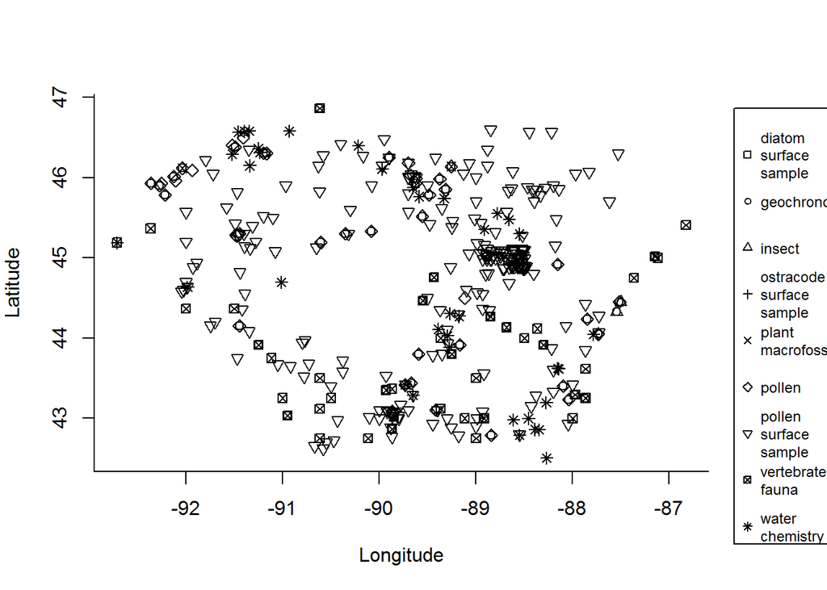

All Neotoma data points in Wisconsin, with varying symbols

```r
plot(all_wi)
```

So, we can see the different dataset types, you can pretty much make out Wisconsin, but it kind of looks like poop. We can make a better map, an interactive map, using leaflet. That’s pretty fun, and the [RStudio help page for `leaflet`](https://rstudio.github.io/leaflet/) is really great to get you started. Make sure the `leaflet` package is installed, and then let’s check out what we get:

```r
library(leaflet)
```

```r
# We're going to use this multiple times I think, so let's make it a function:

leaflet_map <- function(dataset_in) {
  dataset_summary <- do.call(rbind, lapply(dataset_in,
                        function(x){
                          data.frame(name = x$site.data$site.name,
                                     lat  = x$site.data$lat + runif(1, -0.005, 0.005),
                                     long = x$site.data$long + runif(1, -0.005, 0.005),
                                     type = x$dataset.meta$dataset.type)
                        }))

  # The leaflet package documentation uses piping.  For the sake of this tutorial, I won't:
  pal <- colorFactor("Dark2", domain = levels(dataset_summary$type))

  map <- leaflet(data = dataset_summary)
  map <- leaflet::addTiles(map)
  map <- leaflet::addCircleMarkers(map, ~long, ~lat,
                                   popup = ~paste0("Site: ", as.character(name), "<br>",
                                                   "Type: ",
                                                   as.character(dataset_summary$type)),
                                   color = ~pal(type),
                                   stroke = FALSE, fillOpacity = 0.5)
  map
}

leaflet_map(all_wi)
```

[interactive chart not shown]

This is much nicer (I think), but it is still missing all the additional information. We can go directly to the Neotoma Explorer using the `browse` function. Unfortunately, because f the limitations of URL string length, this doesn’t always work:

```r
# Does not work:
neotoma::browse(all_wi)

# Does work:
some_wi <- neotoma::get_dataset(gpid = "Wisconsin", datasettype = "pollen")
neotoma::browse(some_wi)
```

Yay!

## Plotting stratigraphic diagrams

Let’s say we’re looking for all records from Wisconsin with *Larix* pollen, that must have some samples within the middle Holocene:

```r
some_wi <- neotoma::get_dataset(gpid = "Wisconsin", datasettype = "pollen", taxonname = "Larix%", ageyoung = 4000, ageold = 6000)
```

```
## The API call was successful, you have returned 18 records.
```

```r
wi_pollen <- neotoma::get_download(some_wi, verbose = FALSE)
leaflet_map(some_wi) # This is the function we made above.
```

[interactive chart not shown]

What do these records look like?

```r
wi_pollen
```

```
## A download_list containing 18 objects:
## Accessed from 2016-10-13 22:08h to 2016-10-13 22:08h.
## Datasets:
##  dataset.id           site.name      long      lat age.younger age.older
##        3473 Lake Mary           -89.90000 46.25000         200     10345
##         684 Devils Lake         -89.73205 43.41780           0     13614
##         700 Disterhaft Farm Bog -89.16694 43.91694         699     13840
##         860 Gass Lake           -87.73333 44.05000           0     15612
##        1447 Kellys Hollow       -90.35000 45.30000         -29     10000
##        3452 Kellys Hollow       -90.35000 45.30000         -29     10730
##        1448 Kellners Lake       -87.84806 44.23806         -23     14094
##        3781 Stewart's Dark Lake -91.45000 45.30000         482     10649
##        2011 Radtke Lake         -88.10000 43.40000           0     11483
##        3620 Seidel              -87.51556 44.45000          32     11227
##        2624 Tamarack Creek      -91.45000 44.15000           0      4500
##        3035 Wood Lake           -90.08333 45.33333           0     13101
##       15302 Emrick Lake         -89.59428 43.80016         -57     11878
##       15740 Hemlock Lake        -91.19829 46.30730         -42     10877
##       15925 Lake O' Pines       -89.25530 46.14043         -47     12854
##       16129 Lima Bog            -88.84320 42.78895         -31     18406
##       17304 Capitola Lake       -89.55507 45.51958         -40     13288
##       17387 Beaver Lake         -88.15694 44.91960         -30      5103
##    type
##  pollen
##  pollen
##  pollen
##  pollen
##  pollen
##  pollen
##  pollen
##  pollen
##  pollen
##  pollen
##  pollen
##  pollen
##  pollen
##  pollen
##  pollen
##  pollen
##  pollen
##  pollen
```

I like Devil’s Lake, so let’s take a look at the pollen. To get this to work you need the `analogue` package:

```r
library(analogue, quietly = TRUE)
```

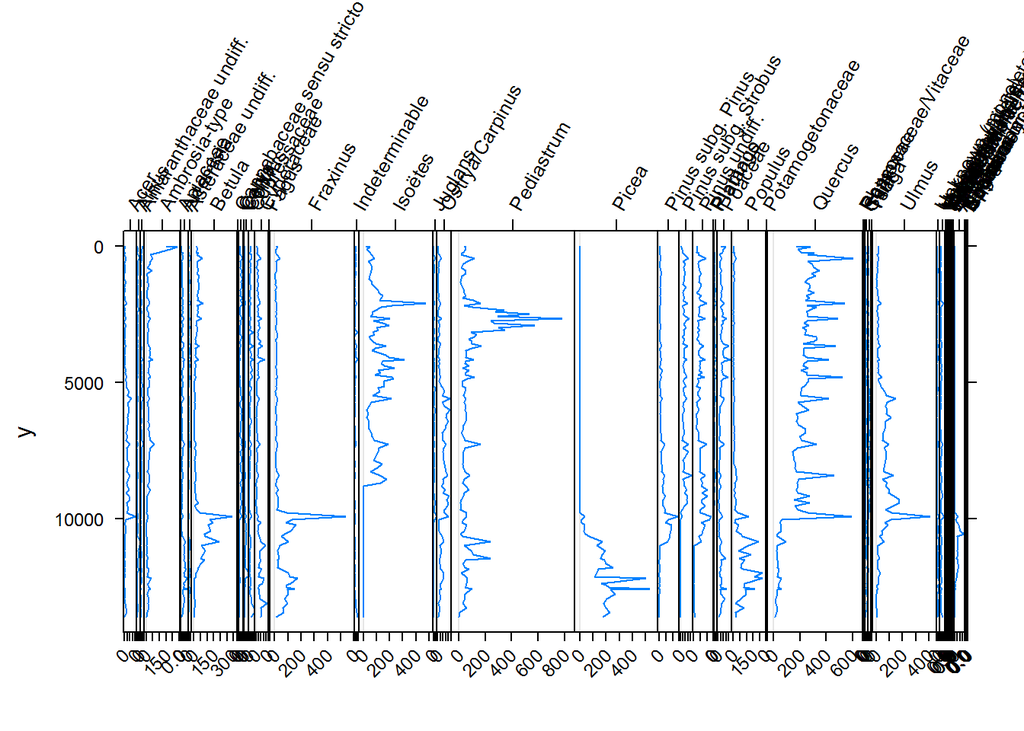

```r
Stratiplot(wi_pollen[[2]])
```

You have all the advantages of the `Stratiplot()` function now, and the wrapper for the `neotoma` package makes it more useful directly with `download` objects.

## Re-building Age-Models

So, I’m interested in the smoothed surface of *Larix* pollen at 4kyr in the region. I’m going to do a lazy job of it, but that’s my perogative. I just want you to see what we might do.

First, we know there are different age types in the records. Let’s see what we’ve got here:

```r
table(sapply(wi_pollen, function(x)x$sample.meta$age.type[1]))
```

```
##
## Calibrated radiocarbon years BP            Radiocarbon years BP
##                               5                              13
```

So, that’s a lot of records to re-do. To do it properly, we need all the chron-controls:

```r
wi_chrons <- neotoma::get_chroncontrol(wi_pollen)
```

```
## API call was successful. Returned chronology.
## API call was successful. Returned chronology.
## API call was successful. Returned chronology.
## API call was successful. Returned chronology.
## API call was successful. Returned chronology.
## API call was successful. Returned chronology.
## API call was successful. Returned chronology.
## API call was successful. Returned chronology.
## API call was successful. Returned chronology.
## API call was successful. Returned chronology.
## API call was successful. Returned chronology.
## API call was successful. Returned chronology.
## API call was successful. Returned chronology.
## API call was successful. Returned chronology.
## API call was successful. Returned chronology.
## API call was successful. Returned chronology.
## API call was successful. Returned chronology.
## API call was successful. Returned chronology.
```

Now, the magic:

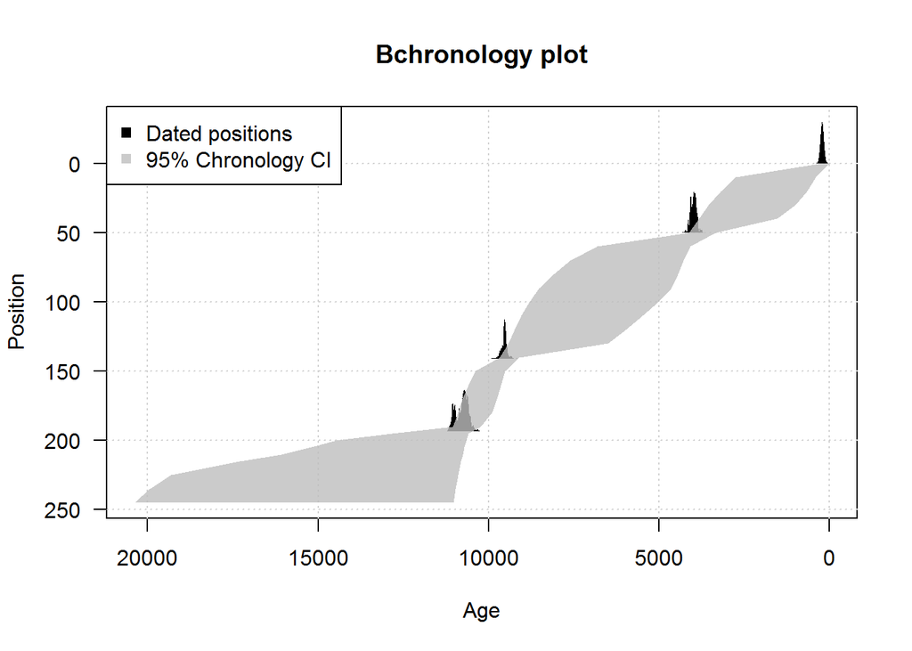

```r
focal <- wi_chrons[[1]]

new_chron <- Bchron::Bchronology(ages   = focal$chron.control$age,
                    ageSds = focal$chron.control$age - focal$chron.control$age.young,
                    positions = focal$chron.control$depth,
                    calCurves = ifelse(focal$chron.control$control.type %in% 'Radiocarbon',
                                       'intcal13', 'normal'),
                    predictPositions = wi_pollen[[1]]$sample.meta$depth)

plot(new_chron)
```

So, you can see that modelling can take a long time, but, we can basically wrap all that logic into a swell little function & run all the models overnight. Wrapping `Bchronology()` around `neotoma`’s `download` objects is something that’s on the TODO list, but there’s a lot of art required to build age models & I’m not sure I want to do that quite yet.

But, let’s just pretend that we’ve done a good job and added all these date into the models.

```r
all_output <- neotoma::compile_downloads(wi_pollen)

all_output[,11:ncol(all_output)] <- all_output[,11:ncol(all_output)] /
  rowSums(all_output[,11:ncol(all_output)], na.rm = TRUE)

larix_df <- data.frame(lat = all_output$lat,
                       long = all_output$long,
                       age = all_output$age,
                       larix = rowSums(all_output[,grep("Larix", colnames(all_output))],
                                       na.rm = TRUE))

lar_model <- mgcv::gam(larix ~ s(lat, long, age), data = larix_df, family = binomial)
```

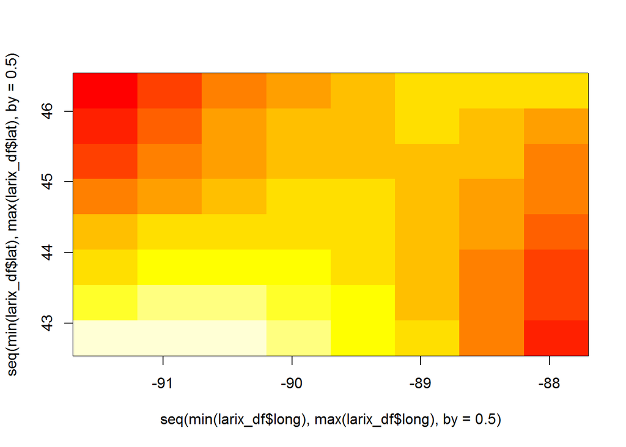

```r
lar_predict <- expand.grid(lat  = seq(min(larix_df$lat),
                                      max(larix_df$lat), by = 0.5),
                           long = seq(min(larix_df$long),
                                      max(larix_df$long), by = 0.5),
                           age  = 4000)

lar_predict$pred <- predict(lar_model, newdata = lar_predict)

image(y = seq(min(larix_df$lat), max(larix_df$lat), by = 0.5),
      x = seq(min(larix_df$long), max(larix_df$long), by = 0.5),
      z = matrix(lar_predict$pred, ncol = length(unique(lar_predict$long))))
```

### Finding records by Handle

Someties people only publish their records using handles:

```r
data_ca <- get_dataset(datasettype = "pollen", gpid = "Canada")
```

```
## The API call was successful, you have returned 453 records.
```

```r
data_us <- get_dataset(datasettype = "pollen", gpid = "United States")
```

```
## The API call was successful, you have returned 1014 records.
```

```r
datasets <- bind(data_ca, data_us)

handles <- sapply(datasets, function(x)x$dataset.meta$collection.handle)

codes <- c("JACKSON","ARRINGTO","BINNEWTR","WOLFCRK","CAMEL","ROCKYHOC","TULANEG","ANDERSON","CLEARPND","QUICKSND","SANDYRUN","WHITEPND","ALEXISLK")

test_datasets <- sapply(codes, function(x)grep(paste0("^", x, "$"), handles))
output <- datasets[test_datasets]
class(output) <- c("dataset_list", "list")

leaflet_map(output)
```

[interactive chart not shown]